# EMG modelling

Johannes Zauner, Lucien Bickerstaff

2026-02-03

# Setup

```r
# Seed for reproducibility
set.seed(2025)

# Libraries
library(here)
library(tidyverse)
library(LightLogR)
library(patchwork)
library(lme4)
library(visreg)
library(mgcv)
```

```r
library(sjPlot)
library(broom.mixed)
library(MuMIn)
```

# EMG data

```r
# Import EMG activity data
emg_data <- read_csv(here("data", "emg_pilot_data.csv"))
# create muscle specific response columns
data <- emg_data %>%
  pivot_wider(names_from = channel,
              values_from = emg_response, # Here we take change counts and not % of change!
              names_prefix = "emg_response_"
              )
```

## Visualize

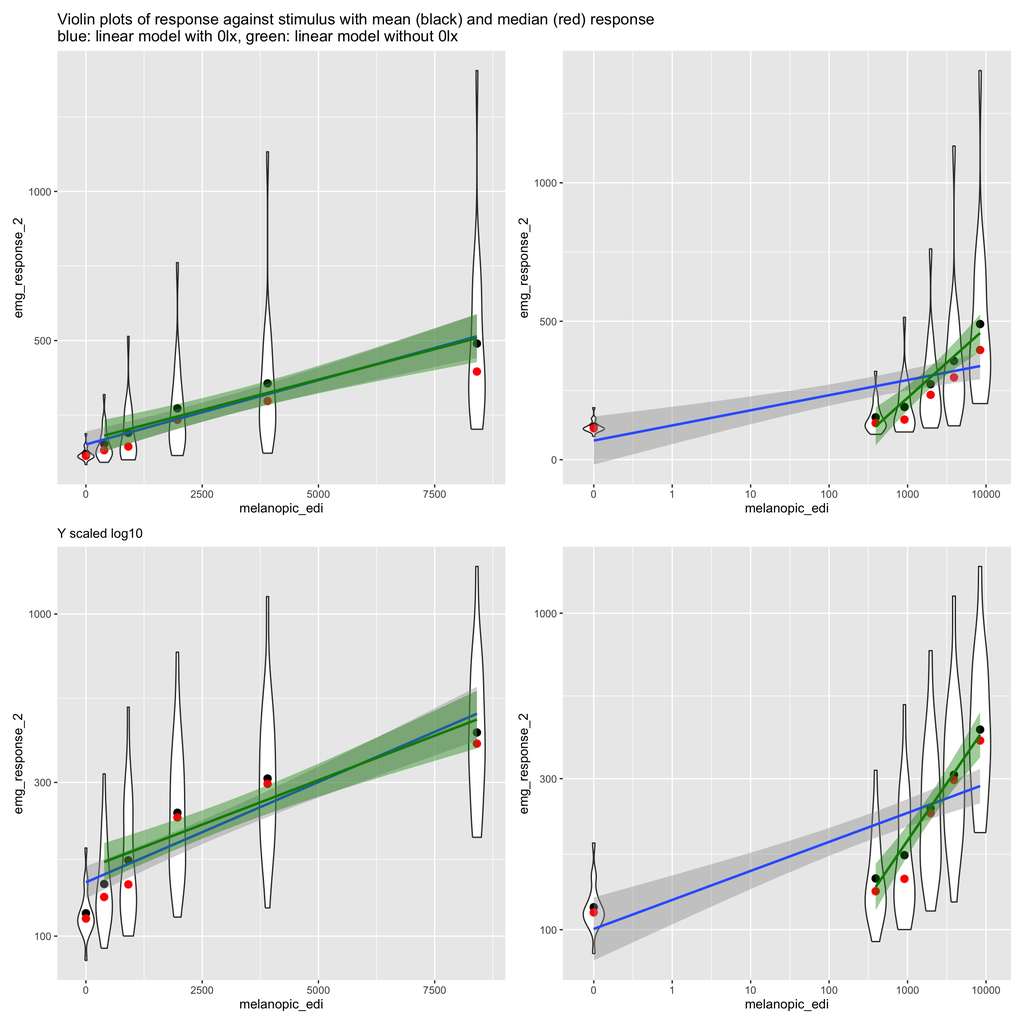

```r
# We take orbicularis oculi response (response_2)
Plot_unscaled <-
data |>
  ggplot(aes(y = emg_response_2, x = melanopic_edi)) +
  geom_violin(aes(group = melanopic_edi), scale = "width") +
  stat_summary(aes(group = melanopic_edi), fun = mean) +
  stat_summary(aes(group = melanopic_edi), fun = median, col = "red", size = 0.5) +
  labs(title = "Violin plots of response against stimulus with mean (black) and median (red) response\nblue: linear model with 0lx, green: linear model without 0lx") +
  geom_smooth(method = "lm") +
  geom_smooth(aes(group = melanopic_edi == 0), col = "green4", fill = "green4",
              method = "lm")

Plot_scaled <-
  Plot_unscaled +
  scale_x_continuous(trans = "symlog", breaks = c(0,10^(0:5))) +
  labs(title = NULL)

Plot_unscaled_log10 <-
  Plot_unscaled +
    scale_y_log10() +
  labs(title = NULL, subtitle = "Y scaled log10")

Plot_scaled_log10 <-
  Plot_scaled +
  scale_y_log10()

(Plot_unscaled + Plot_scaled) /
(Plot_unscaled_log10 + Plot_scaled_log10)
```

## Model

Including random intercept for pid

```r
data <-
data |>
  mutate(is.zero = melanopic_edi == 0,
         log_mel_edi = pmax(melanopic_edi, 1) |> log10())

m1_formula <- log10(emg_response_2) ~ is.zero + log_mel_edi + (1| participant_id)
m0_formula <- log10(emg_response_2) ~ log_mel_edi + (1| participant_id)

model1 <- lmer(m1_formula, data   = data)
model0 <- lmer(m0_formula, data   = data)

summary(model1)
```

```
## Linear mixed model fit by REML ['lmerMod']
## Formula: log10(emg_response_2) ~ is.zero + log_mel_edi + (1 | participant_id)
##    Data: data
##
## REML criterion at convergence: -107.9
##
## Scaled residuals:
##      Min       1Q   Median       3Q      Max
## -3.13591 -0.59801  0.03686  0.59131  2.13355
##
## Random effects:
##  Groups         Name        Variance Std.Dev.
##  participant_id (Intercept) 0.02192  0.1481
##  Residual                   0.01282  0.1132
## Number of obs: 108, groups:  participant_id, 18
##
## Fixed effects:
##             Estimate Std. Error t value
## (Intercept)  1.19768    0.09155   13.08
## is.zeroTRUE  0.87328    0.08875    9.84
## log_mel_edi  0.36138    0.02560   14.12
##
## Correlation of Fixed Effects:
##             (Intr) i.TRUE
## is.zeroTRUE -0.882
## log_mel_edi -0.915  0.944
```

```r
summary(model0)
```

```
## Linear mixed model fit by REML ['lmerMod']
## Formula: log10(emg_response_2) ~ log_mel_edi + (1 | participant_id)
##    Data: data
##
## REML criterion at convergence: -44.9
##
## Scaled residuals:
##     Min      1Q  Median      3Q     Max
## -2.5660 -0.6963 -0.1510  0.6951  2.3317
##
## Random effects:
##  Groups         Name        Variance Std.Dev.
##  participant_id (Intercept) 0.01962  0.1401
##  Residual                   0.02663  0.1632
## Number of obs: 108, groups:  participant_id, 18
##
## Fixed effects:
##             Estimate Std. Error t value
## (Intercept)  1.99198    0.04935   40.36
## log_mel_edi  0.12351    0.01216   10.16
##
## Correlation of Fixed Effects:
##             (Intr)
## log_mel_edi -0.672
```

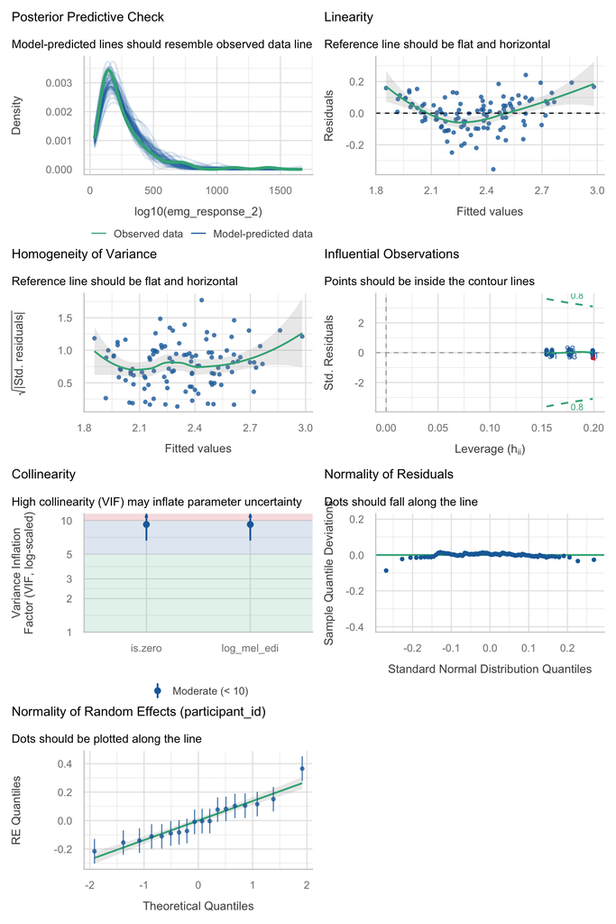

```r
performance::check_model(model1)
```

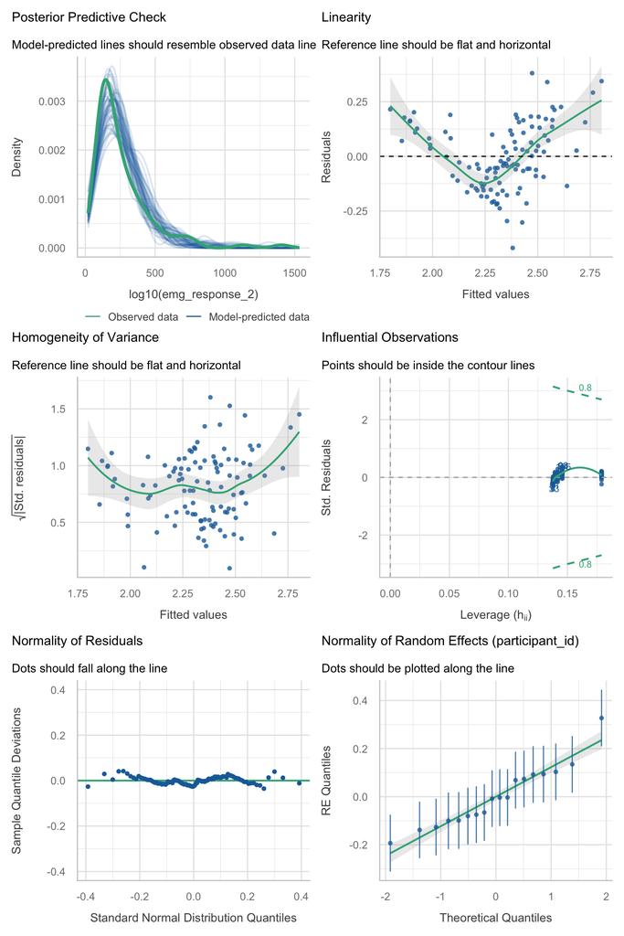

```r
performance::check_model(model0)
```

```r
anova(model0, model1)
```

```
## refitting model(s) with ML (instead of REML)
```

```
## Data: data
## Models:
## model0: log10(emg_response_2) ~ log_mel_edi + (1 | participant_id)
## model1: log10(emg_response_2) ~ is.zero + log_mel_edi + (1 | participant_id)
##        npar      AIC      BIC logLik -2*log(L)  Chisq Df Pr(>Chisq)
## model0    4  -48.701  -37.972 28.350   -56.701
## model1    5 -113.489 -100.078 61.745  -123.489 66.788  1  3.023e-16 ***
## ---
## Signif. codes:  0 '***' 0.001 '**' 0.01 '*' 0.05 '.' 0.1 ' ' 1
```

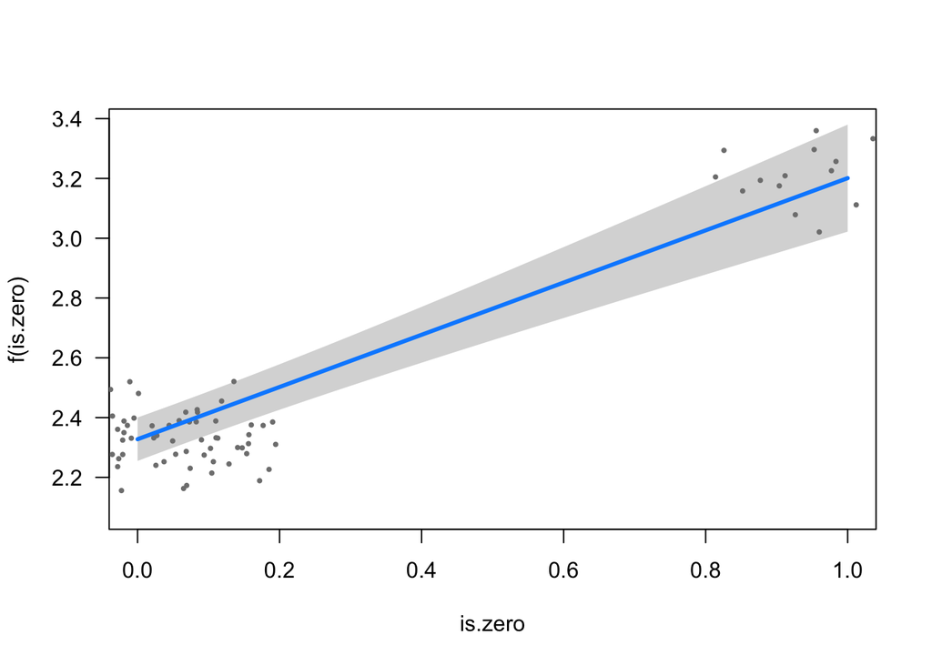

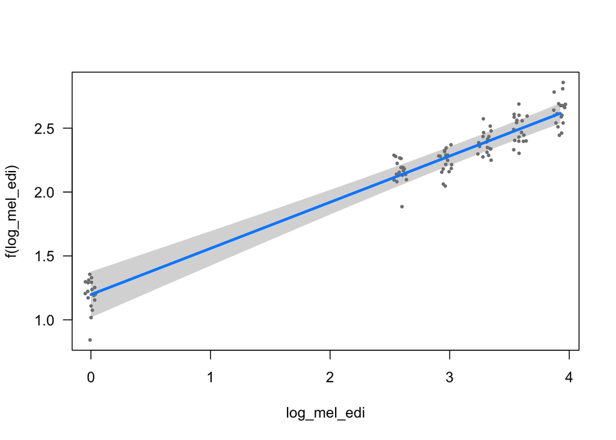

```r
visreg(model1, jitter = TRUE)
```

Not a perfect fit, but good enough diagnostics. Better than the Gamma model.

### Checking whether the dependency is log linear around the data

This is done to see whether if we free the modelling approach from the linearity assumption, does it capture non-linear behaviour that we might have overlooked?

```r
data$log_mel_shift <- log(data$melanopic_edi + 1)

m_gamm <- gam(
  emg_response_2 ~ s(log_mel_shift, k = 6) +
    s(participant_id, bs = "re"),
  family = Gamma(link = "log"),
  data = data
)

summary(m_gamm)
```

```
##
## Family: Gamma
## Link function: log
##
## Formula:
## emg_response_2 ~ s(log_mel_shift, k = 6) + s(participant_id,
##     bs = "re")
##
## Parametric coefficients:
##             Estimate Std. Error t value Pr(>|t|)
## (Intercept)  5.45776    0.04909   111.2   <2e-16 ***
## ---
## Signif. codes:  0 '***' 0.001 '**' 0.01 '*' 0.05 '.' 0.1 ' ' 1
##
## Approximate significance of smooth terms:
##                         edf Ref.df     F p-value
## s(log_mel_shift)  2.221e+00  2.559 37.69  <2e-16 ***
## s(participant_id) 1.321e-05  1.000  0.00   0.581
## ---
## Signif. codes:  0 '***' 0.001 '**' 0.01 '*' 0.05 '.' 0.1 ' ' 1
##
## R-sq.(adj) =  0.357   Deviance explained = 55.1%
## GCV = 0.20285  Scale est. = 0.25602   n = 108
```

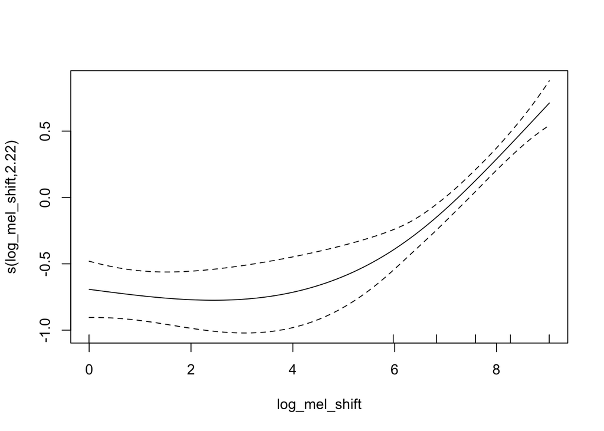

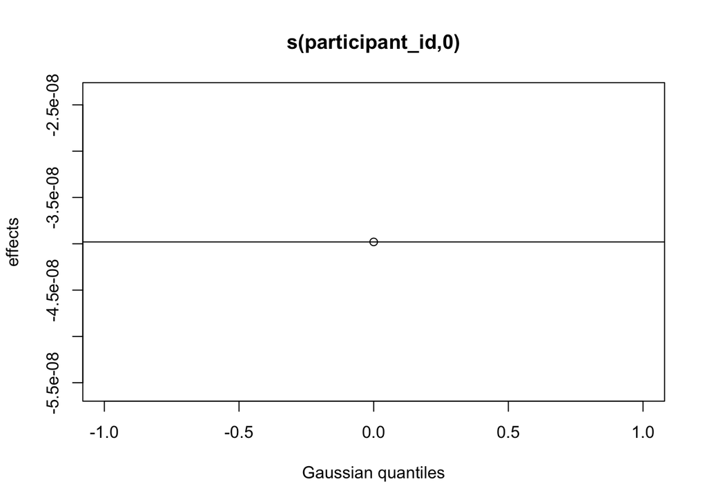

```r
plot(m_gamm, all.terms = TRUE)
```

Looking good:

That is a generalized additive mixed model. It does not assume a linear relationship between the variables and thus is useful if we want to assess whether a non-linear relationship agrees with our linear model - in the relevant region, that is. So if we only look to the right of the plot - that is where the non-zero Mel EDI data are. And there we don’t see relevant non-linearities, so our approach is not missing anything important. You can see where our data are by the small lines sticking up from the x-axis

# Saving final model

The model including is.zero is a better fit. We drop participant-dependent slopes as they prevent models from converging.

```r
saveRDS(model1, here("outputs", "models", "emg_lmm.rds"))
```

# Manuscript-ready outputs

```r
tab_model(
  model1,
  show.re.var = TRUE,   # show random-effect SD/variance
  show.icc = TRUE,      # intraclass correlation
  show.r2 = TRUE,       # pseudo-R² if available
  pred.labels = c("Intercept", "is.zeroTRUE", "log_mel_edi"),
  dv.labels = "emg_response",
  file = here("outputs", "models", "model_table.html")
)
```

|  | emg_response |  |  |
| --- | --- | --- | --- |
| Predictors | Estimates | CI | p |
| Intercept | 1.20 | 1.02 – 1.38 | **<0.001** |
| is.zeroTRUE | 0.87 | 0.70 – 1.05 | **<0.001** |
| log_mel_edi | 0.36 | 0.31 – 0.41 | **<0.001** |
| Random Effects |  |  |  |
| σ<sup>2</sup> | 0.01 |  |  |
| τ<sub>00</sub> <sub>participant_id</sub> | 0.02 |  |  |
| ICC | 0.63 |  |  |
| N <sub>participant_id</sub> | 18 |  |  |
| Observations | 108 |  |  |
| Marginal R<sup>2</sup> / Conditional R<sup>2</sup> | 0.518 / 0.822 |  |  |

```r
coef_table <- tidy(model1, effects = "fixed", conf.int = TRUE)
coef_table
```

```
## # A tibble: 3 × 7
##   effect term        estimate std.error statistic conf.low conf.high
##   <chr>  <chr>          <dbl>     <dbl>     <dbl>    <dbl>     <dbl>
## 1 fixed  (Intercept)    1.20     0.0915     13.1     1.02      1.38
## 2 fixed  is.zeroTRUE    0.873    0.0887      9.84    0.699     1.05
## 3 fixed  log_mel_edi    0.361    0.0256     14.1     0.311     0.412
```

```r
r2 <- r.squaredGLMM(model1)
r2
```

```
##            R2m       R2c
## [1,] 0.5177119 0.8220023
```